# Credit Worthiness Scoring Model

### Linkedin: [https://www.linkedin.com/in/vamshi-indla]

## Objective

The purpose of this analysis is to demonstrate the analytical techniques to evaluate credit worthiness of an applicant. These techniques are applied by Major banks and Financial Institutions. I will use the Credit Approval Dataset which is a collection of credit card applications and the credit approval decisions. The data is available from the UCI Machine Learning Repository. The techniques include data visualization, logistical regression, random forest, support vector machines, boosted classification trees.

This analysis is organized as follows:

-Generate several data visualizations to understand the underlying data; -Perform data transformations as needed; -Develop research questions about the data; and -Generate and apply the model to answer the research questions.

## Exploratory Analysis and Data Transformations

The first step in any analysis is to obtain the dataset and codebook. Both the dataset and the codebook can be downloaded for free from the UCI website. A quick review of the codebook shows that all of the values in the dataset have been converted to meaningless symbols to protect the confidentiality of the data. This will still suit our purposes as a demonstration dataset, since we are not using the data to develop actual credit screening criteria. However, to make it easier to work with the dataset, I gave the variables working names based on the type of data.

```r
### read comma separated file into memory
setwd("/Users/vamshi294/Downloads/Kaggle/R_Credit_Scoring_Prototype/")
data <- read.csv("crx.data.txt",stringsAsFactors = F)
colnames(data)[1]<- "Male"
colnames(data)[2]<- "Age"
colnames(data)[3]<- "Debt"
colnames(data)[4]<- "Married"
colnames(data)[5]<- "Bankcustomer"
colnames(data)[6]<- "EducationLevel"
colnames(data)[7]<- "Ethnicity"
colnames(data)[8]<- "YearsEmployed"
colnames(data)[9]<- "PriorDefault"
colnames(data)[10]<- "Employed"
colnames(data)[11]<- "CreditScore"
colnames(data)[12]<- "DriversLicense"
colnames(data)[13]<- "Citizen"
colnames(data)[14]<- "ZipCode"
colnames(data)[15]<- "Income"
colnames(data)[16]<- "Approved"

data$Age <- as.numeric(data$Age)
v_numeric <- names(data)[which(sapply(data, is.numeric))]
data$Approved[data$Approved=='-'] <- 'no'
data$Approved[data$Approved=='+'] <- 'yes'
data$Approved <- as.factor(data$Approved)
```

### Data Transformations

As previously mentioned the binary values, such as Approved, need to be converted to 1s and 0s. We’ll need to do additional transformations such as filling in missing values. That process begins by first identifying which values are missing and then determining the best way to address them. We can remove them, zero them out, or estimate a plug value. A scan through the dataset shows that missing values are labeled with ‘?’. For each variable, we’ll convert the missing values to NA which R will interpret differently than a character value.

### Continuous Values (Linear Regression and Descriptive Statistics)

To start with, we will use the summary() function to see the descriptive statistics of the numeric values such as min, max, mean, and median. The range is the difference between the minimum and maximum values and can be calculated from the summary() output. For the B variable, the range is 66.5 and the standard deviation is 11.9667.

```r
summary(data[,v_numeric])
```

```
##       Age             Debt        YearsEmployed     CreditScore
##  Min.   :13.75   Min.   : 0.000   Min.   : 0.000   Min.   : 0.000
##  1st Qu.:22.58   1st Qu.: 1.000   1st Qu.: 0.165   1st Qu.: 0.000
##  Median :28.42   Median : 2.750   Median : 1.000   Median : 0.000
##  Mean   :31.57   Mean   : 4.766   Mean   : 2.225   Mean   : 2.402
##  3rd Qu.:38.25   3rd Qu.: 7.250   3rd Qu.: 2.625   3rd Qu.: 3.000
##  Max.   :80.25   Max.   :28.000   Max.   :28.500   Max.   :67.000
##  NA's   :12
##      Income
##  Min.   :     0
##  1st Qu.:     0
##  Median :     5
##  Mean   :  1019
##  3rd Qu.:   396
##  Max.   :100000
##
```

### Missing Values

```r
cor(na.omit(data[,v_numeric]))
```

```
##                      Age      Debt YearsEmployed CreditScore     Income
## Age           1.00000000 0.2023670    0.39575039  0.18589715 0.01853611
## Debt          0.20236700 1.0000000    0.30077302  0.27148338 0.12158871
## YearsEmployed 0.39575039 0.3007730    1.00000000  0.32702575 0.05331075
## CreditScore   0.18589715 0.2714834    0.32702575  1.00000000 0.06330123
## Income        0.01853611 0.1215887    0.05331075  0.06330123 1.00000000
```

We can use this information to create a linear regression model between the two variables. The model produces the two coefficients below: Intercept and YearsEmployed. These coefficients are used to predict future values. The YearsEmployed coefficients is multiplied by the value for YearsEmployed and the intercept is added.

```r
lm_model <- lm(Age ~ YearsEmployed, data=data[,v_numeric])
lm_model
```

```
##
## Call:
## lm(formula = Age ~ YearsEmployed, data = data[, v_numeric])
##
## Coefficients:
##   (Intercept)  YearsEmployed
##        28.447          1.412
```

In item 83, for example, the YearsEmployed value is 3. The formula is then 3 x 1.412399 + 28.446953= 32.6841489. This method was used to estimate all 12 missing values in the Age variable.

```r
tempage <- predict.lm(lm_model,data=data$YearsEmployed)
data$Age[is.na(data$Age)] <- tempage[is.na(data$Age)]
```

### Descriptive Statistics

The next step of working with continuous variables is to standardize them or calculate the z-score. First, we use the mean and standard deviation calculated above. Then, subtract the mean from each value and, finally, divide by the standard deviation. The end result is the z-score. When we plot the histograms, the distribution looks the same but the z-scores are easier to work with because the values are measured in standard deviations instead of raw values. One thing to note is that the data is skewed to the right because the tail is longer.

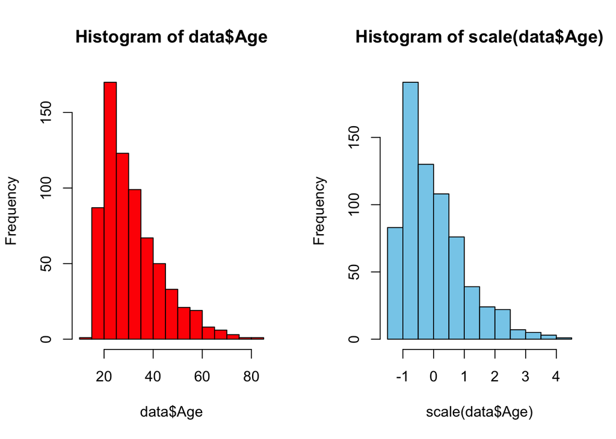

```r
par(mfrow=c(1,2))
hist(data$Age,col='red')
hist(scale(data$Age),col='skyblue')
```

```r
data$AgeNorm <- scale(data$Age)
```

Now that we have an understanding of how this variable is distributed, we can compare the credit status by value of AgeNorm. We’ll use a boxplot showing the mean value for each group and the quartiles. We can tell from the boxplot, that the median of the two groups is slightly different with the age of approved applications being slightly closer to the mean than the denied applications. We can also see that the interquartile range is greater on the ‘Approved’ than the others. We can interpret these facts as the credit applicants with lower Age values are less likely to be granted credit, however there are several outlying applicants with high values that still were not granted credit.

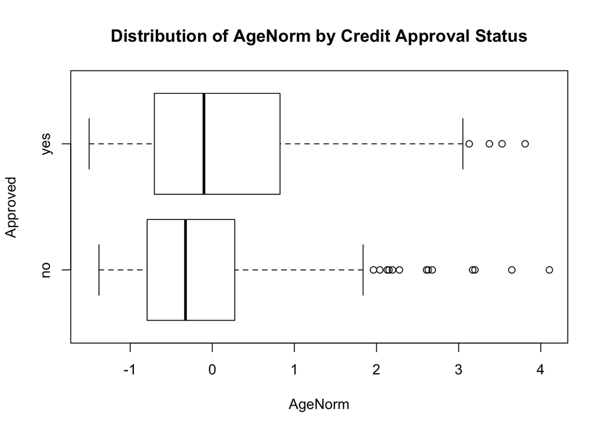

```r
boxplot(data$AgeNorm ~ data$Approved,
        main="Distribution of AgeNorm by Credit Approval Status",
        xlab="AgeNorm", ylab="Approved",horizontal=T)
```

Similar transformations on the other continuous variables are performed and then plotted them. From the boxplots, we can see the distribution is different between the variables. Income has the least amount of variance because the boxes are tightly grouped about the mean. By examining the histograms we can see that the data is skewed to the right meaning the median is less than the mean. The datasets could be good candidates for logarithmic transformation.

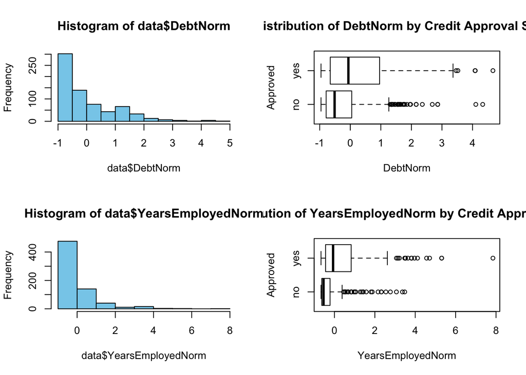

```r
data$DebtNorm <- scale(data$Debt)
data$YearsEmployedNorm <- scale(data$YearsEmployed)
data$CreditScoreNorm <- scale(data$CreditScore)
data$IncomeNorm <- scale(data$Income)

par(mfrow=c(2,2))
hist(data$DebtNorm,col='skyblue')
boxplot(data$DebtNorm ~ data$Approved,
        main="Distribution of DebtNorm by Credit Approval Status",
        xlab="DebtNorm", ylab="Approved",horizontal=T)
hist(data$YearsEmployedNorm,col='skyblue')
boxplot(data$YearsEmployedNorm ~ data$Approved,
        main="Distribution of YearsEmployedNorm by Credit Approval Status",
        xlab="YearsEmployedNorm", ylab="Approved",horizontal=T)
```

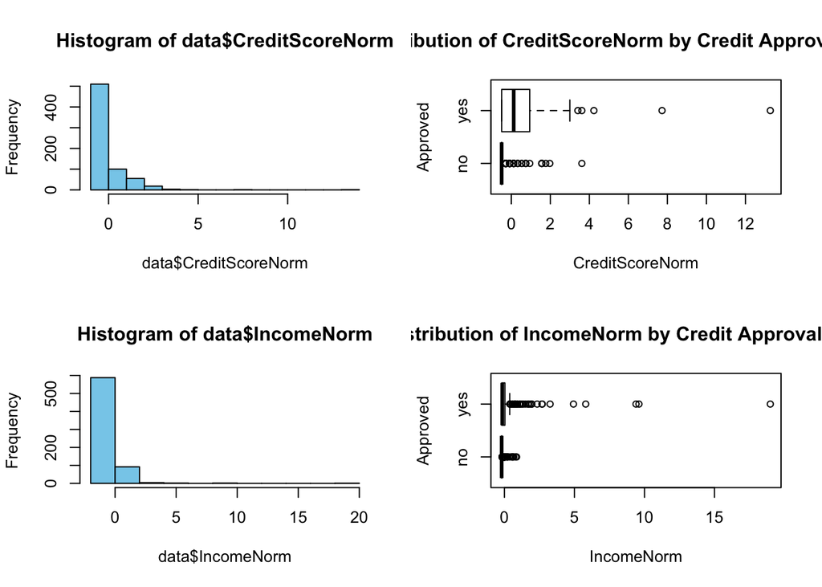

```r
par(mfrow=c(2,2))
hist(data$CreditScoreNorm,col='skyblue')
boxplot(data$CreditScoreNorm ~ data$Approved,
        main="Distribution of CreditScoreNorm by Credit Approval Status",
        xlab="CreditScoreNorm", ylab="Approved",horizontal=T)
hist(data$IncomeNorm,col='skyblue')
boxplot(data$IncomeNorm ~ data$Approved,
        main="Distribution of IncomeNorm by Credit Approval Status",
        xlab="IncomeNorm", ylab="Approved",horizontal=T)
```

The charts below show the continuous variables after first taking the log of each value, and then converting it to normalized value similar to above. The boxplots seem to add more informational value now because for each dataset the mean of the approved applications is further distributed from the mean of those denied. This difference will help the classifier algorithm to distinguish between the values later. We should specifically notice for the IncomeLog and CreditScoreLog variables that the applicants that did not receive credit were still heavily skewed to the right when compared to those that were granted credit. This means that a low IncomeLog or CreditScoreLog score is likely a good predictor for making the application decision. We can test this observation by using the significance in the models later.

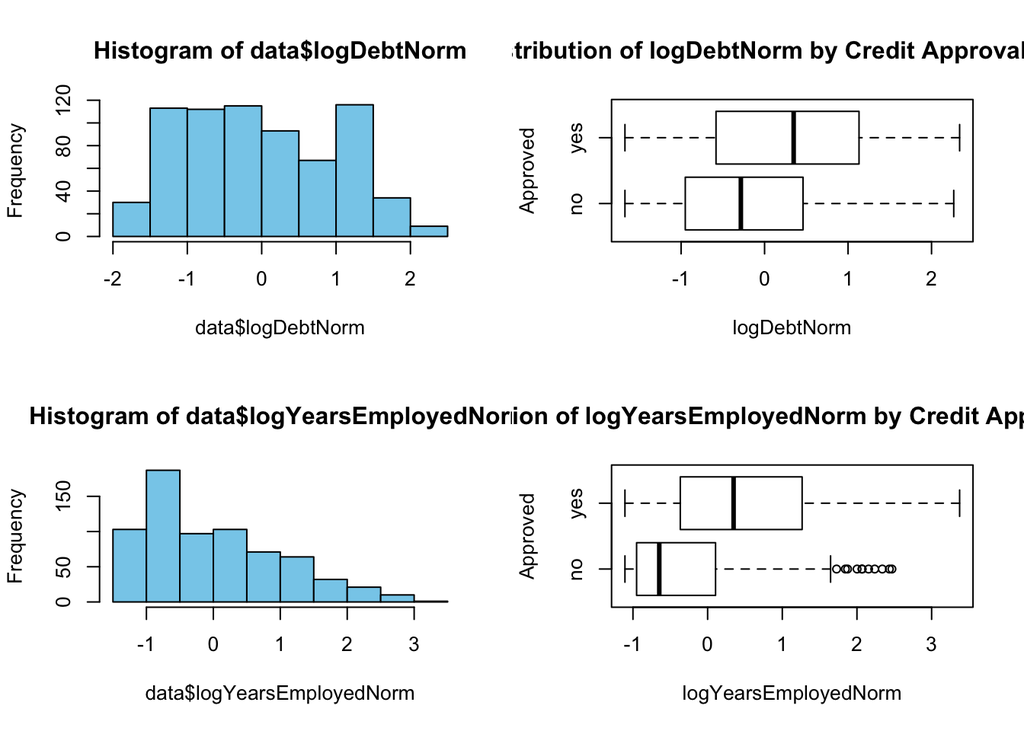

```r
data$logAgeNorm <- scale(log(data$Age+1))
data$logDebtNorm <- scale(log(data$Debt+1))
data$logYearsEmployedNorm <- scale(log(data$YearsEmployed+1))
data$logCreditScoreNorm <- scale(log(data$CreditScore+1))
data$logIncomeNorm <- scale(log(data$Income+1))

par(mfrow=c(2,2))
hist(data$logDebtNorm,col='skyblue')
boxplot(data$logDebtNorm ~ data$Approved,
        main="Distribution of logDebtNorm by Credit Approval Status",
        xlab="logDebtNorm", ylab="Approved",horizontal=T)
hist(data$logYearsEmployedNorm,col='skyblue')
boxplot(data$logYearsEmployedNorm ~ data$Approved,
        main="Distribution of logYearsEmployedNorm by Credit Approval Status",
        xlab="logYearsEmployedNorm", ylab="Approved",horizontal=T)
```

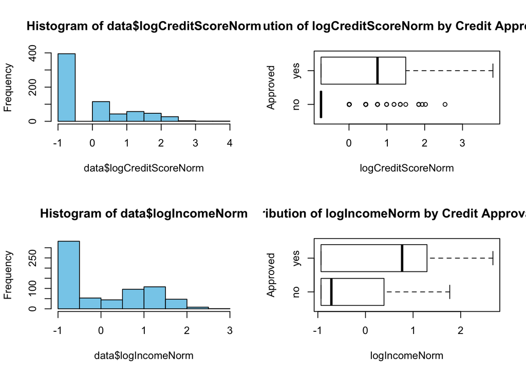

```r
par(mfrow=c(2,2))
hist(data$logCreditScoreNorm,col='skyblue')
boxplot(data$logCreditScoreNorm ~ data$Approved,
        main="Distribution of logCreditScoreNorm by Credit Approval Status",
        xlab="logCreditScoreNorm", ylab="Approved",horizontal=T)
hist(data$logIncomeNorm,col='skyblue')
boxplot(data$logIncomeNorm ~ data$Approved,
        main="Distribution of logIncomeNorm by Credit Approval Status",
        xlab="logIncomeNorm", ylab="Approved",horizontal=T)
```

### Categorical Variables (Association Rules)

```r
# Create the function.
getmode <- function(v) {
   uniqv <- unique(v)
   uniqv[which.max(tabulate(match(v, uniqv)))]
}

# Calculate the mode using the user function.
data$Male[data$Male=='?'] <- getmode(data$Male)
data$Male[data$Male=='b'] <- 1
data$Male[data$Male=='a'] <- 0
data$Male <-as.integer(data$Male)

table(data$Male)
```

```
##
##   0   1
## 210 479
```

A more complex method, and perhaps accurate method, would be to use association rules to estimate the missing values. Association rules look at the different combinations of values that each of the rows can take and then provides a method for determining the most likely or least likely state. As an example, row 248 is missing a value for the ‘Male’ column and we want to use rules to determine the most likely value it would have. We would look at the values in the other columns: Married = u, BankCustomer = g, and EducationLevel = c etcetera and then look to all of the other rows to find the combination that most clearly matches those in row 248. In set notation the rule would look like this: {u,g,c} => {1}. The apriori algorithm can be used to generate the rules or combinations and then select the best one based on a few key metrics.

Support: Support is how often the left hand side of the rule occurs in the dataset. In our example above, we would count how many times {u,g,c} occurs and divide by the total number of transactions.

Confidence: Confidence measures how often a rule is true. First, we find the subset of all transactions that contain {u,g,c}. Of this subset, we then count the number of transactions that match the right hand side of rule, or {1}. The confidence ratio is calculated by taking the number of times the rule is true and dividing it by the number of times the left hand side occurs.

### Variable Selection

Split the data into train and test.

```r
library(caret)
trainIndex <- createDataPartition(data$Approved, p = .75, list=FALSE, times=1)
train <- data[trainIndex,]
test <- data[-trainIndex,]
```

Boruta package can help in determining the important variables. It can be seen that variables DriversLicense, Citizenship, Gender(Male) are insignificant, and hence they are excluded from predictors

```r
library(Boruta)
set.seed(123)
boruta.train <- Boruta(Approved~., data = train, doTrace = 2)
```

[output not shown]

[output not shown]

[output not shown]

[output not shown]

[output not shown]

[output not shown]

[output not shown]

[output not shown]

[output not shown]

[output not shown]

[output not shown]

[output not shown]

[output not shown]

[output not shown]

[output not shown]

[output not shown]

[output not shown]

[output not shown]

[output not shown]

[output not shown]

[output not shown]

[output not shown]

[output not shown]

[output not shown]

[output not shown]

[output not shown]

[output not shown]

[output not shown]

[output not shown]

[output not shown]

[output not shown]

[output not shown]

[output not shown]

[output not shown]

[output not shown]

[output not shown]

[output not shown]

[output not shown]

[output not shown]

[output not shown]

[output not shown]

[output not shown]

[output not shown]

[output not shown]

[output not shown]

[output not shown]

[output not shown]

[output not shown]

[output not shown]

[output not shown]

[output not shown]

[output not shown]

[output not shown]

[output not shown]

[output not shown]

[output not shown]

[output not shown]

[output not shown]

[output not shown]

[output not shown]

[output not shown]

[output not shown]

[output not shown]

[output not shown]

[output not shown]

[output not shown]

[output not shown]

[output not shown]

[output not shown]

[output not shown]

[output not shown]

[output not shown]

[output not shown]

[output not shown]

[output not shown]

[output not shown]

[output not shown]

[output not shown]

[output not shown]

[output not shown]

[output not shown]

[output not shown]

[output not shown]

[output not shown]

[output not shown]

[output not shown]

[output not shown]

[output not shown]

[output not shown]

[output not shown]

[output not shown]

[output not shown]

[output not shown]

[output not shown]

[output not shown]

[output not shown]

[output not shown]

[output not shown]

[output not shown]

[output not shown]

[output not shown]

[output not shown]

[output not shown]

[output not shown]

[output not shown]

[output not shown]

[output not shown]

```r
print(boruta.train)
```

```
## Boruta performed 99 iterations in 28.23905 secs.
##  20 attributes confirmed important: Age, AgeNorm, CreditScore,
## CreditScoreNorm, Debt and 15 more.
##  4 attributes confirmed unimportant: Citizen, DriversLicense,
## Ethnicity, Male.
##  1 tentative attributes left: Bankcustomer.
```

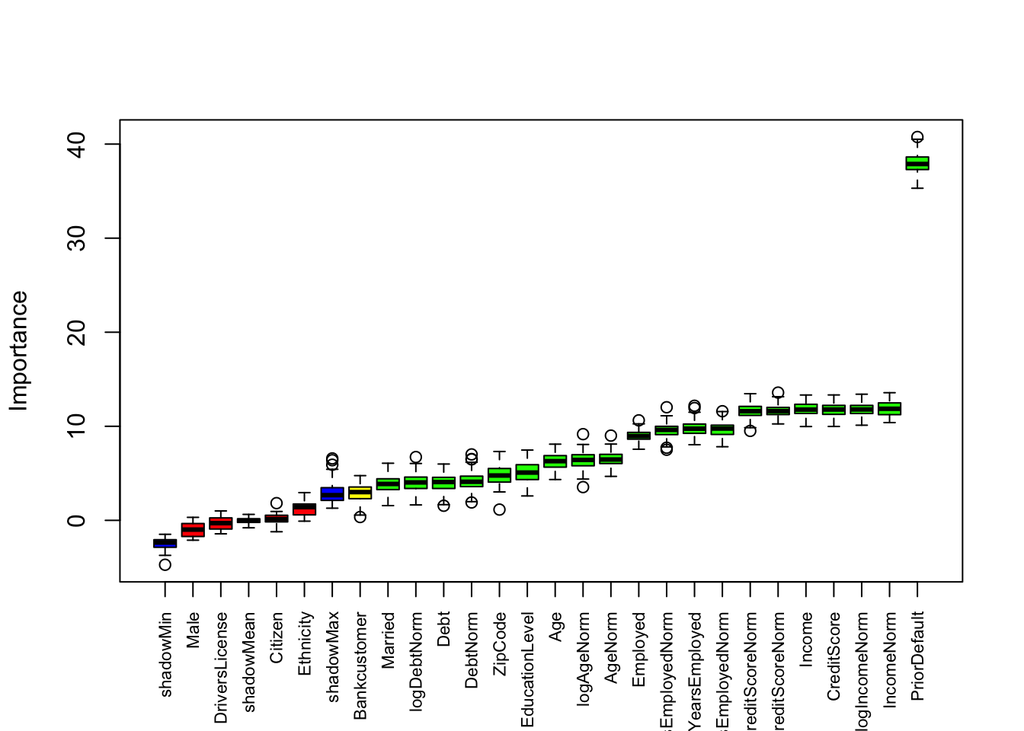

```r
plot(boruta.train, xlab = "", xaxt = "n")

lz<-lapply(1:ncol(boruta.train$ImpHistory),function(i)
    boruta.train$ImpHistory[is.finite(boruta.train$ImpHistory[,i]),i])
names(lz) <- colnames(boruta.train$ImpHistory)
Labels <- sort(sapply(lz,median))

axis(side = 1,las=2,labels = names(Labels),
       at = 1:ncol(boruta.train$ImpHistory), cex.axis = 0.7)
```

```r
final.boruta <- TentativeRoughFix(boruta.train)
print(final.boruta)
```

```
## Boruta performed 99 iterations in 28.23905 secs.
## Tentatives roughfixed over the last 99 iterations.
##  20 attributes confirmed important: Age, AgeNorm, CreditScore,
## CreditScoreNorm, Debt and 15 more.
##  5 attributes confirmed unimportant: Bankcustomer, Citizen,
## DriversLicense, Ethnicity, Male.
```

```r
boruta.predictors <- getSelectedAttributes(final.boruta, withTentative = F)

boruta.df <- attStats(final.boruta)
class(boruta.df)
```

```
## [1] "data.frame"
```

```r
print(boruta.df)
```

```
##                         meanImp  medianImp      minImp     maxImp
## Male                 -0.9429328 -0.9838015 -2.10983688  0.3192813
## Age                   6.2771237  6.2915645  4.33960846  8.0997719
## Debt                  4.0187808  4.0725145  1.55207520  5.9878833
## Married               3.9191911  3.8671043  1.56734264  6.0710897
## Bankcustomer          2.8564991  3.0029516  0.35379613  4.7546042
## EducationLevel        5.0768275  5.0792607  2.59458218  7.4719714
## Ethnicity             1.3093092  1.4073591 -0.08664993  2.9495789
## YearsEmployed         9.7670069  9.7461140  8.04130305 12.1831921
## PriorDefault         37.9831454 37.8846359 35.30616141 40.7545500
## Employed              8.9877703  8.9630039  7.56069115 10.6314359
## CreditScore          11.7603941 11.7848238  9.98080897 13.3319681
## DriversLicense       -0.3121323 -0.2966490 -1.43197921  1.0026479
## Citizen               0.2046300  0.1374654 -1.21070731  1.8291732
## ZipCode               4.7634271  4.7680794  1.14500305  7.3201759
## Income               11.8127842 11.7741197  9.97325696 13.3252992
## AgeNorm               6.5363004  6.4670967  4.67496729  9.0104971
## DebtNorm              4.1328554  4.1018579  1.90155720  7.0110800
## YearsEmployedNorm     9.6941365  9.7594104  7.82727069 11.6012713
## CreditScoreNorm      11.6434379 11.6179489 10.25078611 13.5822341
## IncomeNorm           11.8711116 11.8623104 10.39339998 13.5705364
## logAgeNorm            6.3979438  6.4253075  3.53512766  9.1637392
## logDebtNorm           4.0643471  4.0318563  1.64136734  6.7302962
## logYearsEmployedNorm  9.5431031  9.6143716  7.50549329 12.0241838
## logCreditScoreNorm   11.6386023 11.5980757  9.50888250 13.4655306
## logIncomeNorm        11.7781706 11.7874283 10.11386315 13.4110373
##                       normHits  decision
## Male                 0.0000000  Rejected
## Age                  1.0000000 Confirmed
## Debt                 0.8383838 Confirmed
## Married              0.7777778 Confirmed
## Bankcustomer         0.5151515  Rejected
## EducationLevel       0.8888889 Confirmed
## Ethnicity            0.0000000  Rejected
## YearsEmployed        1.0000000 Confirmed
## PriorDefault         1.0000000 Confirmed
## Employed             1.0000000 Confirmed
## CreditScore          1.0000000 Confirmed
## DriversLicense       0.0000000  Rejected
## Citizen              0.0000000  Rejected
## ZipCode              0.8989899 Confirmed
## Income               1.0000000 Confirmed
## AgeNorm              0.9898990 Confirmed
## DebtNorm             0.7878788 Confirmed
## YearsEmployedNorm    1.0000000 Confirmed
## CreditScoreNorm      1.0000000 Confirmed
## IncomeNorm           1.0000000 Confirmed
## logAgeNorm           0.9898990 Confirmed
## logDebtNorm          0.7979798 Confirmed
## logYearsEmployedNorm 1.0000000 Confirmed
## logCreditScoreNorm   1.0000000 Confirmed
## logIncomeNorm        1.0000000 Confirmed
```

```r
boruta.predictors <- c(boruta.predictors,'Approved')
train <- train[boruta.predictors]
test <- test[boruta.predictors]
```

### Generate Analytic Models

In order to prepare and apply a model to this dataset, we’ll first have to break it into two subsets. The first will be the training set on which we will develop the model. The second will be the test dataset which we will use to test the accuracy of our model. We will allocate 75% of the items to Training and 25% items to the Test set.

Once our dataset has been split, we can establish a baseline model for predicting whether a credit application will be approved. This baseline model will be used as a benchmark to determine how effective the models are. First, we determine the percentage of credit card applications that were approved in the training set: There are 518 applications and 288 or 56% of which were denied. Since more applications were denied, our baseline model will predict that all applications were declined This simple model would be correct 56% of the time. Our models have to be more accurate than 56% to add value to the business.

### Logistic Regression

Create the Model Regression models are useful for predicting continuous (numeric) variables. However, the target value in Approved is binary and can only be values of 1 or 0. The applicant can either be issued a credit card or denied- they cannot receive a partial credit card. We could use linear regression to predict the approval decision using threshold and anything below assigned to 0 and anything above is assigned to 1. Unfortunately, the predicted values could be well outside of the 0 to 1 expected range. Therefore, linear or multivariate regression will not be effective for predicting the values. Instead, logistic regression will be more useful because it will produce probability that the target value is 1. Probabilities are always between 0 and 1 so the output will more closely match the target value range than linear regression.

```r
## Define control function to handle optional arguments for train function
## Models to be assessed based on largest absolute area under ROC curve
cv.ctrl <- trainControl(method = "repeatedcv", repeats = 3,
                        summaryFunction = twoClassSummary,
                        classProbs = TRUE)

### Logistic (Generalized Linear Model)
log.model.1 <- train(Approved ~ logAgeNorm + logDebtNorm + logYearsEmployedNorm + logCreditScoreNorm + logIncomeNorm,                data = train, method = "glm", metric = "ROC", trControl = cv.ctrl)
summary(log.model.1)
```

```
##
## Call:
## NULL
##
## Deviance Residuals:
##     Min       1Q   Median       3Q      Max
## -2.3760  -0.7535  -0.4902   0.6799   2.1419
##
## Coefficients:
##                      Estimate Std. Error z value Pr(>|z|)
## (Intercept)          -0.17088    0.11218  -1.523    0.128
## logAgeNorm            0.03993    0.11723   0.341    0.733
## logDebtNorm           0.01587    0.11756   0.135    0.893
## logYearsEmployedNorm  0.68162    0.12497   5.454 4.92e-08 ***
## logCreditScoreNorm    1.02871    0.13799   7.455 8.98e-14 ***
## logIncomeNorm         0.47415    0.11856   3.999 6.35e-05 ***
## ---
## Signif. codes:  0 '***' 0.001 '**' 0.01 '*' 0.05 '.' 0.1 ' ' 1
##
## (Dispersion parameter for binomial family taken to be 1)
##
##     Null deviance: 711.59  on 517  degrees of freedom
## Residual deviance: 505.12  on 512  degrees of freedom
## AIC: 517.12
##
## Number of Fisher Scoring iterations: 5
```

```r
# Only 3 variables are significant
log.model.2 <- train(Approved ~  logYearsEmployedNorm + logCreditScoreNorm + logIncomeNorm ,
    data = train, method = "glm", metric = "ROC", trControl = cv.ctrl)
summary(log.model.2)
```

```
##
## Call:
## NULL
##
## Deviance Residuals:
##     Min       1Q   Median       3Q      Max
## -2.3742  -0.7532  -0.4870   0.6793   2.1250
##
## Coefficients:
##                      Estimate Std. Error z value Pr(>|z|)
## (Intercept)           -0.1705     0.1121  -1.521    0.128
## logYearsEmployedNorm   0.6967     0.1177   5.918 3.25e-09 ***
## logCreditScoreNorm     1.0303     0.1367   7.539 4.73e-14 ***
## logIncomeNorm          0.4756     0.1185   4.013 5.99e-05 ***
## ---
## Signif. codes:  0 '***' 0.001 '**' 0.01 '*' 0.05 '.' 0.1 ' ' 1
##
## (Dispersion parameter for binomial family taken to be 1)
##
##     Null deviance: 711.59  on 517  degrees of freedom
## Residual deviance: 505.26  on 514  degrees of freedom
## AIC: 513.26
##
## Number of Fisher Scoring iterations: 5
```

Stepwise Regression, StepAIC, and our gutt says to go ahead with these 3 variables - logYearsEmployedNorm - logCreditScoreNorm  
- logIncomeNorm

```r
### Ada Boost - Boosted Classification Trees

ada.grid <- expand.grid(.iter = c(50, 100),
                        .maxdepth = c(4, 8),
                        .nu = c(0.1, 1))

set.seed(35)
ada.tune <- train(Approved ~ logYearsEmployedNorm + logCreditScoreNorm + logIncomeNorm,
                  data = train ,
                  method = "ada",
                  metric = "ROC",
                  tuneGrid = ada.grid,
                  trControl = cv.ctrl)
ada.tune
```

```
## Boosted Classification Trees
##
## 518 samples
##   3 predictor
##   2 classes: 'no', 'yes'
##
## No pre-processing
## Resampling: Cross-Validated (10 fold, repeated 3 times)
## Summary of sample sizes: 466, 466, 466, 466, 466, 467, ...
## Resampling results across tuning parameters:
##
##   nu   maxdepth  iter  ROC        Sens       Spec
##   0.1  4          50   0.8582950  0.8898604  0.6565217
##   0.1  4         100   0.8559649  0.8700739  0.6652174
##   0.1  8          50   0.8484740  0.8366174  0.7057971
##   0.1  8         100   0.8423431  0.8355501  0.6971014
##   1.0  4          50   0.8414971  0.8319376  0.6869565
##   1.0  4         100   0.8347665  0.8321018  0.6927536
##   1.0  8          50   0.8190726  0.8114122  0.6869565
##   1.0  8         100   0.8179928  0.8044745  0.6811594
##
## ROC was used to select the optimal model using  the largest value.
## The final values used for the model were iter = 50, maxdepth = 4 and nu
##  = 0.1.
```

```r
### Random Forest
rf.grid <- data.frame(.mtry = c(2, 3))
set.seed(35)
library(randomForest)
rf.tune <- train(Approved ~ logYearsEmployedNorm + logCreditScoreNorm + logIncomeNorm,
                data = train ,
                 method = "rf",
                 metric = "ROC",
                 tuneGrid = rf.grid,
                 trControl = cv.ctrl)
rf.tune
```

```
## Random Forest
##
## 518 samples
##   3 predictor
##   2 classes: 'no', 'yes'
##
## No pre-processing
## Resampling: Cross-Validated (10 fold, repeated 3 times)
## Summary of sample sizes: 466, 466, 466, 466, 466, 467, ...
## Resampling results across tuning parameters:
##
##   mtry  ROC        Sens       Spec
##   2     0.8414659  0.8620279  0.6652174
##   3     0.8312728  0.8169951  0.6739130
##
## ROC was used to select the optimal model using  the largest value.
## The final value used for the model was mtry = 2.
```

```r
### Support Vector Machine
set.seed(35)
svm.tune <- train(Approved ~ logYearsEmployedNorm + logCreditScoreNorm + logIncomeNorm,
                  data = train ,
                  method = "svmRadial",
                  tuneLength = 9,
                  preProcess = c("center", "scale"),
                  metric = "ROC",
                  trControl = cv.ctrl)
svm.tune
```

```
## Support Vector Machines with Radial Basis Function Kernel
##
## 518 samples
##   3 predictor
##   2 classes: 'no', 'yes'
##
## Pre-processing: centered (3), scaled (3)
## Resampling: Cross-Validated (10 fold, repeated 3 times)
## Summary of sample sizes: 466, 466, 466, 466, 466, 467, ...
## Resampling results across tuning parameters:
##
##   C      ROC        Sens       Spec
##    0.25  0.8439120  0.8588259  0.6521739
##    0.50  0.8406493  0.8737685  0.6492754
##    1.00  0.8336225  0.8807471  0.6434783
##    2.00  0.8324855  0.8853859  0.6420290
##    4.00  0.8255122  0.8888752  0.6391304
##    8.00  0.8185693  0.8831281  0.6391304
##   16.00  0.8124152  0.8900246  0.6362319
##   32.00  0.8077426  0.8923235  0.6217391
##   64.00  0.8068591  0.8957718  0.6130435
##
## Tuning parameter 'sigma' was held constant at a value of 0.6559673
## ROC was used to select the optimal model using  the largest value.
## The final values used for the model were sigma = 0.6559673 and C = 0.25.
```

### Model Evaluation

With all four models in hand, I can begin to evaluate their performance by whipping together some cross-tabulations of the observed and predicted Approved for the passengers in the train data. caret makes this easy with the confusionMatrix function.

### Logistic regression model

```r
library(e1071)
log.pred <- predict(log.model.2, train)
confusionMatrix(log.pred, train$Approved)
```

```
## Confusion Matrix and Statistics
##
##           Reference
## Prediction  no yes
##        no  248  77
##        yes  40 153
##
##                Accuracy : 0.7741
##                  95% CI : (0.7356, 0.8095)
##     No Information Rate : 0.556
##     P-Value [Acc > NIR] : < 2.2e-16
##
##                   Kappa : 0.535
##  Mcnemar's Test P-Value : 0.0008741
##
##             Sensitivity : 0.8611
##             Specificity : 0.6652
##          Pos Pred Value : 0.7631
##          Neg Pred Value : 0.7927
##              Prevalence : 0.5560
##          Detection Rate : 0.4788
##    Detection Prevalence : 0.6274
##       Balanced Accuracy : 0.7632
##
##        'Positive' Class : no
##
```

```r
# #install.packages("ROCR");
# library(ROCR)
#
# #Prediction function
# ROCRpred = prediction(predictTrain, qualityTrain$PoorCare)
#
# # Performance function
# ROCRperf = performance(ROCRpred, "tpr", "fpr") #This defines what we want to plot on x & y axis
#
# # Plot ROC curve
# plot(ROCRperf)
```

> Accuracy - 77%

Let’s ask some business questions 1. What is the Sensitivity and Specificity of this model?

```r
### ada regression model

ada.pred <- predict(ada.tune, train)
confusionMatrix(ada.pred, train$Approved)
```

```
## Confusion Matrix and Statistics
##
##           Reference
## Prediction  no yes
##        no  274  68
##        yes  14 162
##
##                Accuracy : 0.8417
##                  95% CI : (0.8074, 0.8721)
##     No Information Rate : 0.556
##     P-Value [Acc > NIR] : < 2.2e-16
##
##                   Kappa : 0.6716
##  Mcnemar's Test P-Value : 4.832e-09
##
##             Sensitivity : 0.9514
##             Specificity : 0.7043
##          Pos Pred Value : 0.8012
##          Neg Pred Value : 0.9205
##              Prevalence : 0.5560
##          Detection Rate : 0.5290
##    Detection Prevalence : 0.6602
##       Balanced Accuracy : 0.8279
##
##        'Positive' Class : no
##
```

> Accuracy - 84%

```r
### randomForest regression model

rf.pred <- predict(rf.tune, train)
confusionMatrix(rf.pred, train$Approved)
```

```
## Confusion Matrix and Statistics
##
##           Reference
## Prediction  no yes
##        no  287  40
##        yes   1 190
##
##                Accuracy : 0.9208
##                  95% CI : (0.8942, 0.9426)
##     No Information Rate : 0.556
##     P-Value [Acc > NIR] : < 2.2e-16
##
##                   Kappa : 0.8369
##  Mcnemar's Test P-Value : 2.946e-09
##
##             Sensitivity : 0.9965
##             Specificity : 0.8261
##          Pos Pred Value : 0.8777
##          Neg Pred Value : 0.9948
##              Prevalence : 0.5560
##          Detection Rate : 0.5541
##    Detection Prevalence : 0.6313
##       Balanced Accuracy : 0.9113
##
##        'Positive' Class : no
##
```

> Accuracy - 92%

### SVM model

```r
svm.pred <- predict(svm.tune, train)
confusionMatrix(svm.pred, train$Approved)
```

```
## Confusion Matrix and Statistics
##
##           Reference
## Prediction  no yes
##        no  252  75
##        yes  36 155
##
##                Accuracy : 0.7857
##                  95% CI : (0.7478, 0.8203)
##     No Information Rate : 0.556
##     P-Value [Acc > NIR] : < 2e-16
##
##                   Kappa : 0.5584
##  Mcnemar's Test P-Value : 0.00031
##
##             Sensitivity : 0.8750
##             Specificity : 0.6739
##          Pos Pred Value : 0.7706
##          Neg Pred Value : 0.8115
##              Prevalence : 0.5560
##          Detection Rate : 0.4865
##    Detection Prevalence : 0.6313
##       Balanced Accuracy : 0.7745
##
##        'Positive' Class : no
##
```